# Análise e Modelagem do Consumo de Energia Elétrica no Brasil

Author

Gustavo Almeida Silva - Pedro Henrique Corrêa de Almeida

# 1 Introdução

A energia elétrica é um recurso fundamental para o progresso do Brasil. Desde sua chegada no final do século XIX, com a construção da primeira usina hidrelétrica em Niterói, o setor elétrico brasileiro se desenvolveu rapidamente. Hoje, o Brasil é o quarto maior produtor de energia elétrica na América Latina.

Sua importância para a economia do país é indiscutível, sendo utilizada em diversos setores como indústria, comércio, agricultura e serviços, gerando emprego e renda.

Atualmente, o Brasil é o 7º maior consumidor de energia do mundo e o maior da América do Sul

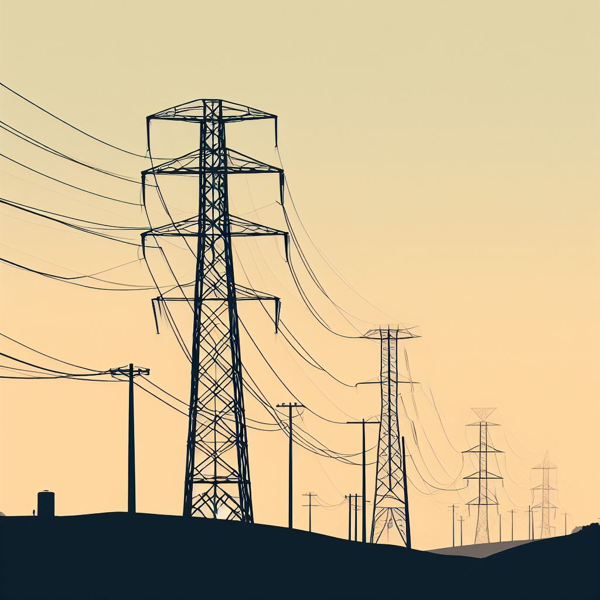

O trabalho desenvolvido nesse documento tem como objetivo, analisar e modelar a série temporal de consumo de energia elétrica no Brasil, entre o período de Janeiro de 2004 a Setembro de 2023

Os dados utilizados foram obtidos da organização [EPE - Empresa de Pesquisa Energética](https://www.epe.gov.br/pt/publicacoes-dados-abertos/publicacoes/consumo-de-energia-eletrica)

Os dados ja limpos e organizados em um csv podem ser acessados via github: [Consumo_Brasil.csv](https://github.com/Gustavo039/TSA_final_exam/blob/main/consumo_eletrico_brasil.csv)

# 2 Análise Exploratória

```r
consumo_ts_br = readr::read_csv('consumo_eletrico_brasil.csv') |>
  select(-"...1") |>
  mutate(ano_mes = ano_mes_dia |> yearmonth(), .keep = 'unused') |>
  relocate(ano_mes, .before = consumo) |>
  tsibble::as_tsibble(index = ano_mes)
```

```r
consumo_ts_br |>
  rmarkdown::paged_table()
```

| ano_mes | consumo |
| --- | --- |
| 2004 jan | 26978358 |
| 2004 fev | 26508171 |
| 2004 mar | 27284329 |
| 2004 abr | 28046182 |
| 2004 mai | 27244506 |
| 2004 jun | 27082961 |
| 2004 jul | 27346005 |
| 2004 ago | 27656858 |
| 2004 set | 28232451 |
| 2004 out | 28556121 |

[output cut: 227 more lines]

A série apresenta o seguinte comportamento

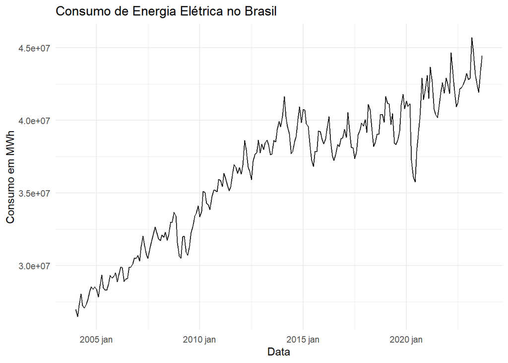

```r
consumo_ts_br |>
  autoplot() +
  theme_minimal() +
  labs(title = 'Consumo de Energia Elétrica no Brasil', x = 'Data', y = 'Consumo em MWh')
```

Vemos que se trata de uma série com uma forte tendência de crescimento. Além disso, é possível observar a presença de uma sazonalidade.

Também vemos grandes quedas no uso de energia nos anos de 2009 e 2020

A queda em 2009 pode ser explicada pela forte crise econômica mundial de 2008, como noticiado em [G1 - Queda do uso de energia 2009](https://g1.globo.com/Noticias/Economia_Negocios/0,,MUL1461892-9356,00-CONSUMO+DE+ENERGIA+NO+BRASIL+RECUA+EM+DIZ+EPE.html): “Como ressaltado ao longo do ano, o mercado brasileiro de energia elétrica sofreu forte impacto da crise financeira internacional, porém seus efeitos se concentraram na classe industrial, como consequência da imediata e profunda retração da atividade deste segmento”

Já a queda em 2020 está fortemente ligada a pandemia de Covid-19, onde os setores industriais apresentaram forte queda nos primeiros meses do ‘lockdown’, como noticiado em [Energe - Queda do uso de energia 2020](https://energes.com.br/consumo-de-energia-no-brasil/) “Ao analisar o desempenho do consumo de energia por ramo de atividade, é possível notar que a indústria automotiva e o segmento têxtil ainda lideram as maiores quedas no mercado livre. O setor de veículos apresentou, no início da pandemia (mês de abril) recuo de 65,6% no consumo de energia. Já a área têxtil registrou retração de 46,3% também no mesmo período.”

```r
# fore = ts(consumo_ts_br$consumo, start = c(year(min(consumo_ts_br$ano_mes)), month(min(consumo_ts_br$ano_mes))), frequency = 12)
#
# ggseasonplot(fore, year.labels=FALSE, continuous=TRUE, polar = TRUE)
```

Buscando melhor entender os dados trabalhados, principalmente sua sazonalidade, o método STL de decomposição de séries temporais foi utilizado

O **Seasonal and Trend decomposition using Loess**(STL) busca decompor a série em 3 componentes: tendência, sazonalidade e parte aleatória

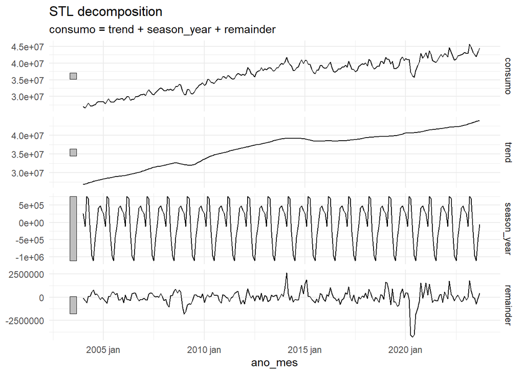

```r
consumo_ts_br |>
  model(
    STL(consumo ~ trend() +
          season(window = "periodic"),
        robust = TRUE)) |>
  components() |>
  autoplot() +
  theme_minimal()
```

A partir da decomposição da série vemos a forte presença de sazonalidade com ciclos anuais, indicando que os modelos com parcelas sazonais serão aqueles com melhor ajuste

Além disso, a parcela aleatória discriminou fortemente a queda no uso de energia de 2020, fato esse que não foi visto para o ano de 2009. Isso indica que os dados do ano de 2020 podem ser mostrar como valores atípicos no etapa de modelagem

# 3 Modelagem

Os seguintes passos foram seguidos:

- Análise da FAC e FACP
  - Utilizar os gráficos de Autocorrelação e Autocorrelação Parcial para investigar o melhor modelo para os dados, assim como os parâmetros desse modelo
- Análise de Variância da Série
  - Visualizar se a série possui variância heterocedástica, onde se necessário, uma transformação deve ser aplicada
- Estimação dos Modelos Não Sazonais e Análise de Resíduos
  - Procura dos melhores parâmetros dos modelos que não possuem uma parcela sazonal
- Estimação dos Modelos Sazonais e Análise de Resíduos
  - Procura dos melhores parâmetros dos modelos que possuem uma parcela sazonal
- Escolha do Melhor Modelo
  - Comparação entre o melhor modelo não sazonal e sazonal, através de métricas como AICc e BIC e valores de acurácia como: REQM, MAE e MAPE calculados a partir de uma validação cruzada

## 3.1 FAC e FACP

Na etapa de análise exploratória vimos que a série trabalhada possui uma forte tendência de crescimento, além de apresentar uma sazonalidade anual

Assim para a aplicação de que suponhem estacionariedade, esperamos que seja necessário pelo menos 1 diferenciação

A série apresentou o seguinte comportamento da FAC e FACP:

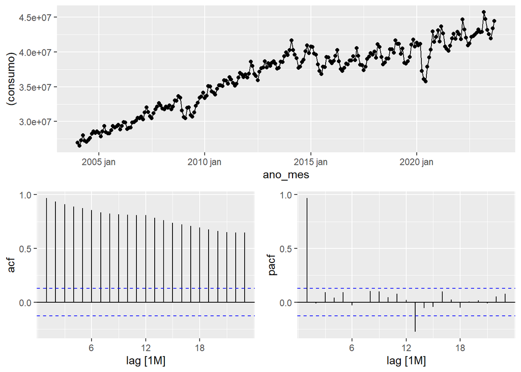

```r
consumo_ts_br |>
  gg_tsdisplay((consumo), plot_type = "partial")
```

Obervando a FAC, vemos um decaimento extremamente lento dos valores de autocorrelações, indicando que a série trabalhada é não estacionária

O teste de **Dickler Fuller Aumentado** com as seguintes hipóteses foi aplicado:

$$H_0: \text{Série é não estacionária}$$

$$H_1: \text{Série é estacionária}$$

```r
consumo_ts_br$consumo |>
  tseries::adf.test(k=12)
```

```
    Augmented Dickey-Fuller Test

data:  consumo_ts_br$consumo
Dickey-Fuller = -1.7759, Lag order = 12, p-value = 0.6701
alternative hypothesis: stationary
```

Assim como era esperado, o teste não rejeitou a hipótese de não estacionariedade da série e portanto uma diferenciação foi aplicada nos dados

A série diferenciada apresentou o seguinte comportamento

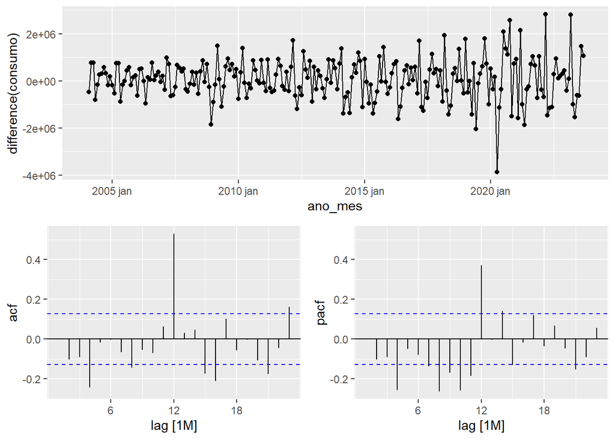

```r
consumo_ts_br |>
  gg_tsdisplay(difference(consumo), plot_type = "partial")
```

A partir de uma diferenciação vemos que a tendência da série foi estabilizada

Aplicando novamente o teste de **Dickler Fuller Aumentado**, o seguinte resultado foi obtido

```r
consumo_ts_br$consumo |>
  diff() |>
  tseries::adf.test(k=12)
```

```
    Augmented Dickey-Fuller Test

data:  diff(consumo_ts_br$consumo)
Dickey-Fuller = -5.0955, Lag order = 12, p-value = 0.01
alternative hypothesis: stationary
```

Onde $H_0$ foi rejeitada e portanto é razoável assumir a sua estacionariedade

## 3.2 Análise da Variância dos Dados

A série diferenciada apresentou o seguinte comportamento

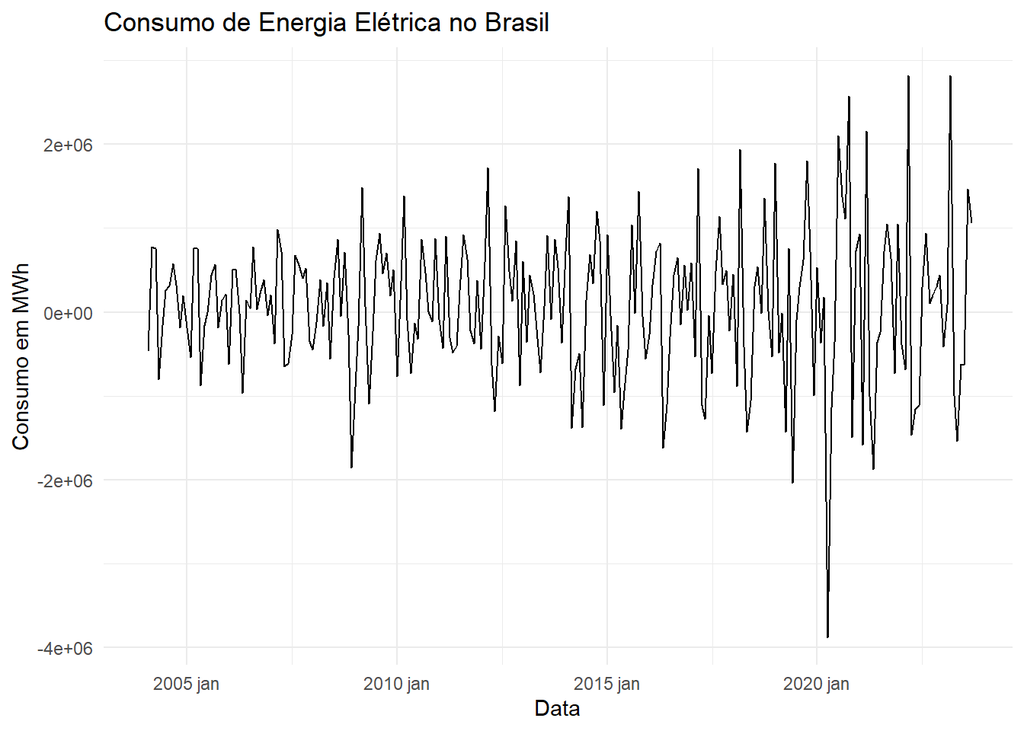

```r
consumo_ts_br |>
  autoplot(consumo |>
             difference()) +
  theme_minimal() +
  labs(title = 'Consumo de Energia Elétrica no Brasil', x = 'Data', y = 'Consumo em MWh')
```

Observando a série, vemos que há um aumento da variância dos dados ao passar dos anos, sendo uma forte indicação de uma série heterocedástica

Para ajustar tal problema, podemos utilizar as seguintes ferramentas:

- Aplicação de uma transformação
  - Uma transformação Log ou Raiz Quadrada
- Modelagem da Variância
  - Utilização de modelos que de média e variância, sendo o **ARCH**(Autoregressive Conditional Heteroskedasticity)o mais conhecido.

A partir do gráfico acima, vemos que o aumento da variância segue um padrão, onde esse aumento ocorre ao longo dos anos, e portanto uma simples transformação Log ou Raiz Quadrada deve reverter tal quadro.

Modelos ARCH possuem são robustos a comportamentos irregulares da variância ao passar do tempo e portanto possuem uma maior complexidade de implementação e interpretação.

Assim, a aplicação de uma transformação **Log** nos dados foi utilizada para a reverter o quadro de heterocedasticidade

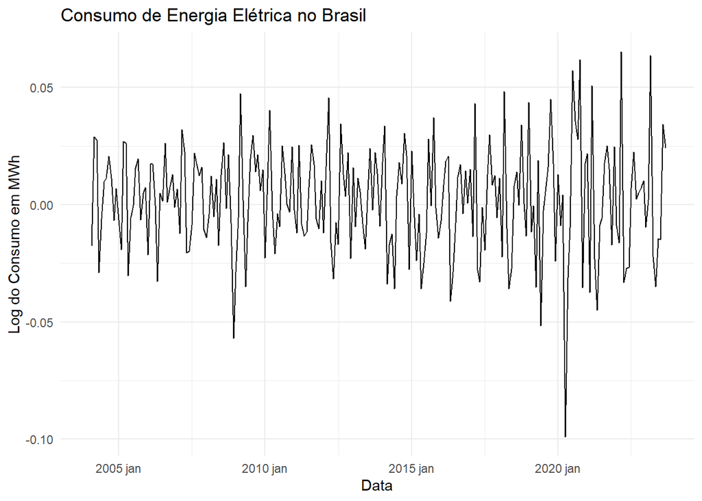

```r
consumo_ts_br |>
  autoplot(consumo |>
             log() |>
             difference()) +
  theme_minimal() +
  labs(title = 'Consumo de Energia Elétrica no Brasil', x = 'Data', y = 'Log do Consumo em MWh')
```

A FAC e FACP tiveram o seguinte desempenho após a aplicação da transformação

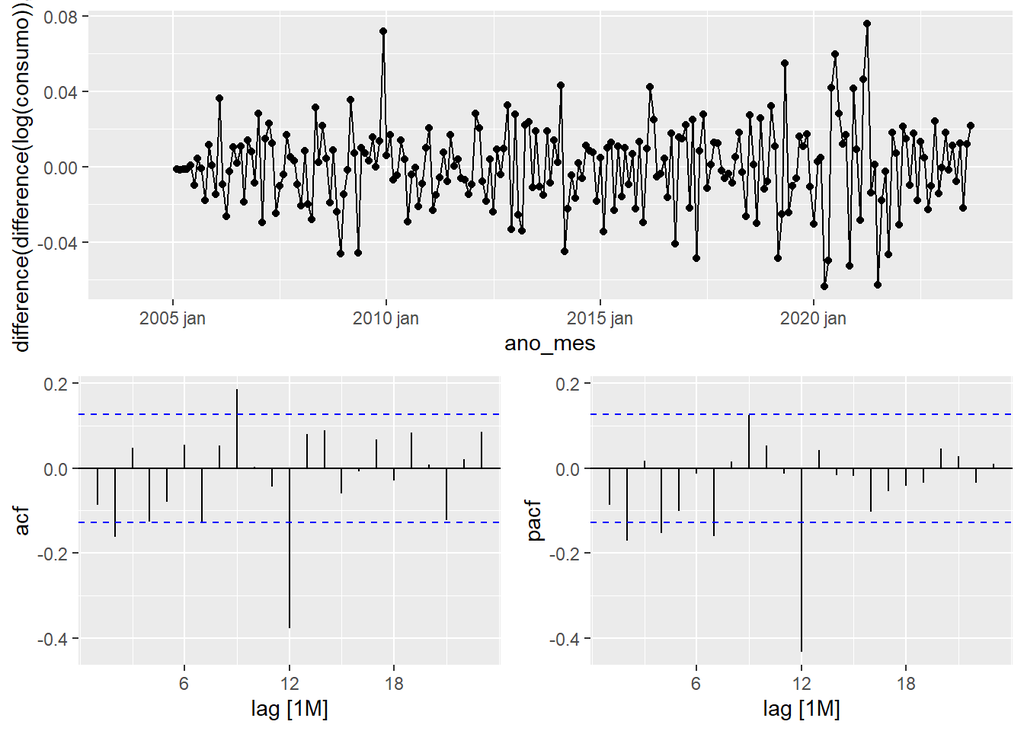

```r
consumo_ts_br |>
  gg_tsdisplay(consumo |>
                 log() |>
                 difference() |>
                 difference(12), plot_type = "partial")
```

## 3.3 Modelos Não Sazonais

O seguinte tópico teve como objetivo estimar modelos ARIMA, onde ao final dessa etapa, o melhor modelo não sazonal foi estimado

O modelo deve ter o parametro de diferenciação igual a 1, dado que os dados trabalhados são não estacionários, onde aplicar 1 diferenciação foi suficiente para alterar tal cenário. Assim, o modelo tem a seguinte estrutura:

$$Seja \ y_t´ = y_t - y_{t-1}$$

$$y_t´ = \phi_1 y´_{t-1} + \phi_2 y´_{t-2} + ... + \phi_p y´_{t-p} + \theta_1 \epsilon_{t-1} + \theta_2 \epsilon_{t-2} + ... + \theta_q \epsilon_{t-q} + \epsilon_t$$

```r
consumo_ts_br  = consumo_ts_br |>
  mutate(log_consumo = log(consumo))


models_arima_br = consumo_ts_br |>
  model(arima_test = ARIMA(log_consumo ~ pdq(0:3, 1, 0:3) + PDQ(0,0,0),
                           trace = T,
                           approximation = F,
                           ic = 'bic'))
```

```
Model specification     Selection metric
ARIMA(2,1,2)(0,0,0)[12]+c   -1113.775835
ARIMA(0,1,0)(0,0,0)[12]+c   -1097.730428
ARIMA(1,1,0)(0,0,0)[12]+c   -1092.415853
ARIMA(0,1,1)(0,0,0)[12]+c   -1092.464672
ARIMA(1,1,2)(0,0,0)[12]+c   -1108.126244
ARIMA(2,1,1)(0,0,0)[12]+c   -1109.848684
ARIMA(2,1,2)(0,0,0)[12]     -1110.558051
ARIMA(2,1,3)(0,0,0)[12]+c   -1108.318818
ARIMA(3,1,2)(0,0,0)[12]+c   -1099.213562
ARIMA(1,1,1)(0,0,0)[12]+c   -1089.231698
ARIMA(1,1,2)(0,0,0)[12]     -1101.434437
ARIMA(1,1,3)(0,0,0)[12]+c   -1103.289867
ARIMA(2,1,1)(0,0,0)[12]     -1102.798620
ARIMA(2,1,3)(0,0,0)[12]     -1105.219996
ARIMA(3,1,1)(0,0,0)[12]+c   -1106.074274
ARIMA(3,1,2)(0,0,0)[12]     -1092.230741
ARIMA(3,1,3)(0,0,0)[12]+c   Inf
```

```r
models_arima_br |> report()
```

```
Series: log_consumo
Model: ARIMA(2,1,2) w/ drift

Coefficients:
         ar1      ar2      ma1     ma2  constant
      1.5742  -0.7916  -1.7028  0.7997     5e-04
s.e.  0.0705   0.0656   0.0690  0.0722     1e-04

sigma^2 estimated as 0.0004637:  log likelihood=573.28
AIC=-1134.56   AICc=-1134.19   BIC=-1113.78
```

O modelo estimado apresentou o seguinte comportamento dos resíduos

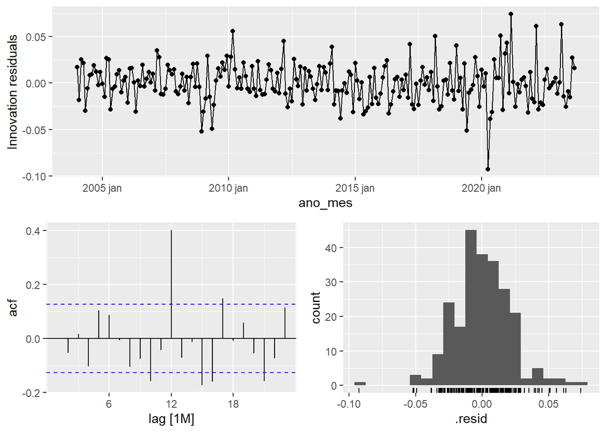

```r
models_arima_br |>
  gg_tsresiduals()
```

A partir do gráfico de FAC, podemos ver um pico de autocorrelação no lag 12, indicando a presença de forte sazonalidade na série assim como explicado na análise exploratória.

Assim, como esperado, um modelo sazonal deve se ajustar melhor aos dados

## 3.4 Modelos Sazonais

O seguinte tópico teve como objetivo estimar modelos SARIMA, onde ao final dessa etapa, o melhor modelo sazonal foi estimado

Ao longo da análise exploratória e da modelagem via modelos não sazonais, vimos que o lag 12 possui uma alta autocorrelação, indicando que tal ponto deve ser modelado a partir de uma parcela sazonal

```r
models_sarima_br = consumo_ts_br |>
  model(arima_test = ARIMA(log_consumo ~ pdq(0:3, 1, 0:3) + PDQ(0:3, 1, 0:3, 12),
                           trace = F,
                           approximation = T,
                           ic = 'bic'))

models_sarima_br |> report()
```

```
Series: log_consumo
Model: ARIMA(1,1,1)(0,1,1)[12]

Coefficients:
         ar1      ma1     sma1
      0.6746  -0.8798  -0.7369
s.e.  0.0908   0.0592   0.0632

sigma^2 estimated as 0.0003453:  log likelihood=577.13
AIC=-1146.27   AICc=-1146.09   BIC=-1132.62
```

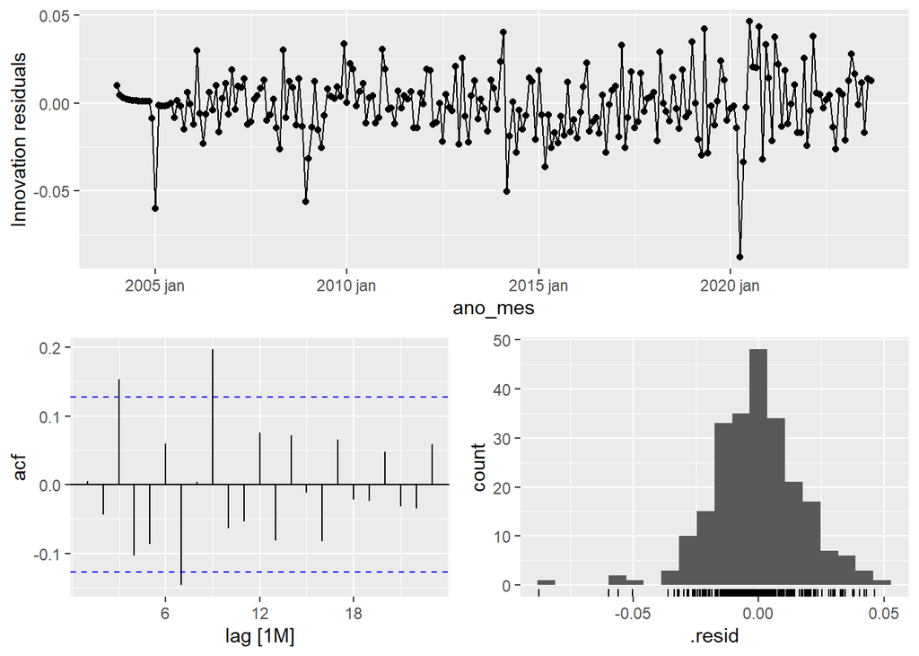

```r
models_sarima_br |>
  gg_tsresiduals()
```

```r
models_sarima_br =  consumo_ts_br |>
  model(arima_test = ARIMA(log_consumo ~ pdq(2,1,2) + PDQ(1,1,1, 12)))

models_sarima_br |> augment()
```

```
# A tsibble: 237 x 6 [1M]
# Key:       .model [1]
   .model      ano_mes log_consumo .fitted   .resid   .innov
   <chr>         <mth>       <dbl>   <dbl>    <dbl>    <dbl>
 1 arima_test 2004 jan        17.1    17.1 0.00988  0.00988
 2 arima_test 2004 fev        17.1    17.1 0.00440  0.00440
 3 arima_test 2004 mar        17.1    17.1 0.00291  0.00291
 4 arima_test 2004 abr        17.1    17.1 0.00219  0.00219
 5 arima_test 2004 mai        17.1    17.1 0.00172  0.00172
 6 arima_test 2004 jun        17.1    17.1 0.00143  0.00143
 7 arima_test 2004 jul        17.1    17.1 0.00123  0.00123
 8 arima_test 2004 ago        17.1    17.1 0.00109  0.00109
 9 arima_test 2004 set        17.2    17.2 0.000986 0.000986
10 arima_test 2004 out        17.2    17.2 0.000898 0.000898
# i 227 more rows
```

```r
models_sarima_br |>
  augment()  |>
  features(.resid, ljung_box, lag = 12)
```

```
# A tibble: 1 x 3
  .model     lb_stat lb_pvalue
  <chr>        <dbl>     <dbl>
1 arima_test    16.2     0.180
```

## 3.5 Escolha do Melhor Modelo

Nos últimos tópicos, ajustados 3 modelos distintos, sendo eles

$$ARIMA(2,1,2). \text{Melhor: BIC, AIC e AICc}$$

$$SARIMA(1,1,1)(0,1,1). \text{Melhor: BIC}$$

Para definirmos o melhor modelo, a capacidade de cada um foi avaliada a partir utilizando método de validação cruzada

```r
consumo_cv = consumo_ts_br |>
  stretch_tsibble(.init = 50, .step = 1)

models_cv = consumo_cv |>
  model(arima_212 = ARIMA(log_consumo ~ pdq(2,1,2) + PDQ(0,0,0)),
        sarima_111_011 = ARIMA(log_consumo ~ pdq(1,1,1) + PDQ(0,1,1)),
        sarima_111_111 = ARIMA(log_consumo ~ pdq(2,1,2) + PDQ(1,1,1)))

models_forecast = models_cv |>
  forecast(h = 1)

models_accuracy = c(models_forecast$.model |> unique())|>
  map_df(\(x)
    models_forecast |>
    filter(.model == x) |>
      accuracy(consumo_ts_br)
  )

models_accuracy |>
  select(.model, RMSE, MAE, MAPE) |>
  rename(Modelo = .model,
         REQM = RMSE,
         EMA = MAE,
         EPMA = MAPE) |>
  mutate_if(is.numeric, ~ round(., 3))
```

```
# A tibble: 3 x 4
  Modelo          REQM   EMA  EPMA
  <chr>          <dbl> <dbl> <dbl>
1 arima_212      0.024 0.019 0.107
2 sarima_111_011 0.02  0.015 0.088
3 sarima_111_111 0.021 0.016 0.091
```

```r
models_accuracy |>
  select(.model, RMSE, MAE, MAPE) |>
  rename(Modelo = .model,
         REQM = RMSE,
         EMA = MAE,
         EPMA = MAPE) |>
  mutate_if(is.numeric, ~ round(., 3)) |>
  rmarkdown::paged_table()
```

| Modelo | REQM | EMA | EPMA |
| --- | --- | --- | --- |
| arima_212 | 0.024 | 0.019 | 0.107 |
| sarima_111_011 | 0.020 | 0.015 | 0.088 |
| sarima_111_111 | 0.021 | 0.016 | 0.091 |

# 4 Interpretação e Previsão

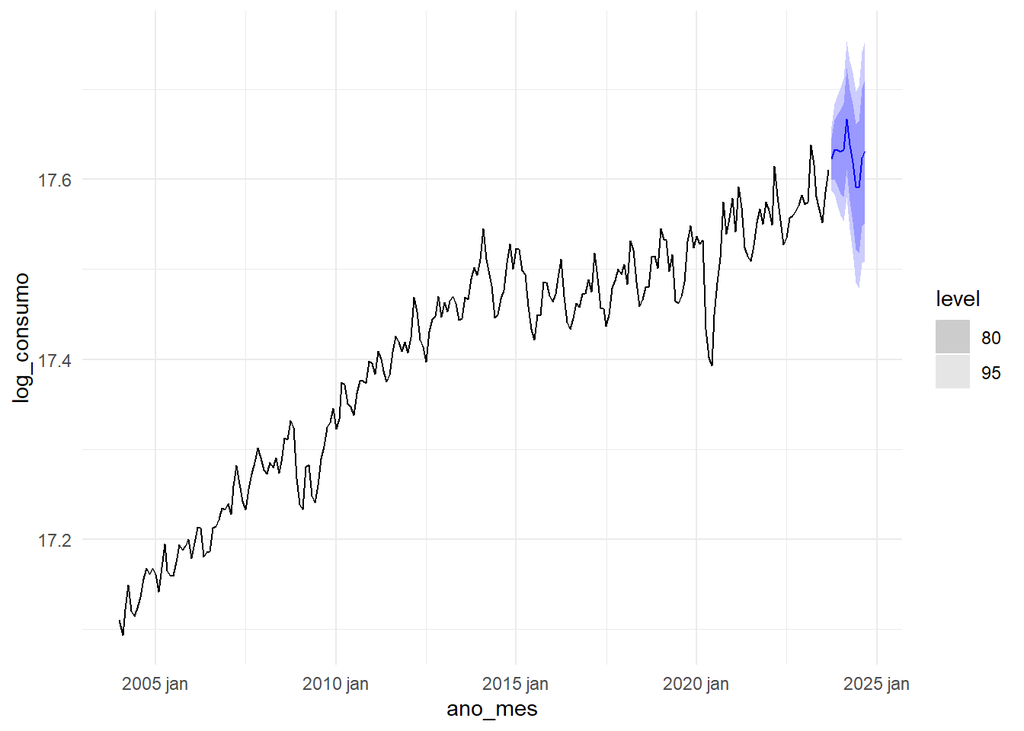

```r
consumo_ts_br |>
  model(sarima_212_111 = ARIMA(log_consumo ~ pdq(2,1,2) + PDQ(1,1,1))) |>
  forecast(h =12) |>
  autoplot(consumo_ts_br) +
  theme_minimal()
```

# 5 Extra - Modelo SARIMAX

Ao longo do estudo, o ano de 2020 se mostrou como uma forte ponto atípico para os modelos

```r
consumo_ts_br = consumo_ts_br |>
  mutate(pandemia = case_when(ano_mes > ymd('2020-03-10') |>
                                yearmonth() &
                              ano_mes < ymd('2020-12-31') |>
                                yearmonth()
                              ~ 1, .default = 0
                              )) |>
  mutate(pandemia = pandemia |> as.factor())
```

```r
sarimax = consumo_ts_br |>
  model(sarimax = ARIMA(log_consumo ~ pandemia + pdq(2,1,1) + PDQ(1,0,0)))

sarimax |> report()
```

```
Series: log_consumo
Model: LM w/ ARIMA(2,1,1)(1,0,0)[12] errors

Coefficients:
         ar1      ar2      ma1    sar1  pandemia1
      0.7201  -0.0911  -0.8553  0.5606    -0.0446
s.e.  0.0919   0.0732   0.0698  0.0567     0.0107

sigma^2 estimated as 0.0003363:  log likelihood=609.49
AIC=-1206.99   AICc=-1206.62   BIC=-1186.2
```

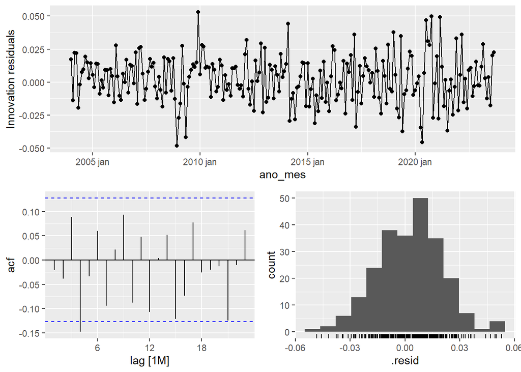

```r
sarimax |> gg_tsresiduals()
```

```r
doParallel::registerDoParallel()

consumo_cv = consumo_ts_br |>
  stretch_tsibble(.init = 30, .step = 1)

models_cv = consumo_cv |>
  model(sarima_212_111 = ARIMA(log_consumo ~ pdq(2,1,2) + PDQ(1,1,1,12)),
        sarimax_212_100 = ARIMA(log_consumo ~ pandemia + pdq(2,1,2) + PDQ(1,0,0,12))
  )


new_data_arg =  consumo_cv |>
  new_data(1) |>
  mutate(pandemia = case_when(ano_mes > ymd('2020-03-11') |>
                                yearmonth() &
                              ano_mes < ymd('2020-12-31') |>
                                yearmonth()
                              ~ 1, .default = 0
                              )) |>
  mutate(pandemia = pandemia |> as.factor())

models_forecast = models_cv |>
  forecast(h = 1, new_data = new_data_arg)

models_accuracy = c(models_forecast$.model |> unique())|>
  map_df(\(x)
    models_forecast |>
    filter(.model == x) |>
      accuracy(consumo_ts_br)
  )

models_accuracy |>
  select(.model, RMSE, MAE, MAPE) |>
  rename(Modelo = .model,
         REQM = RMSE,
         EMA = MAE,
         EPMA = MAPE) |>
  mutate_if(is.numeric, ~ round(., 3))
```

```
# A tibble: 2 x 4
  Modelo           REQM   EMA  EPMA
  <chr>           <dbl> <dbl> <dbl>
1 sarima_212_111  0.02  0.016 0.089
2 sarimax_212_100 0.023 0.018 0.104
```

```r
doParallel::stopImplicitCluster()
```

```r
models_accuracy |>
  select(.model, RMSE, MAE, MAPE) |>
  rename(Modelo = .model,
         REQM = RMSE,
         EMA = MAE,
         EPMA = MAPE) |>
  mutate_if(is.numeric, ~ round(., 3)) |>
  rmarkdown::paged_table()
```

| Modelo | REQM | EMA | EPMA |
| --- | --- | --- | --- |
| sarima_212_111 | 0.020 | 0.016 | 0.089 |
| sarimax_212_100 | 0.023 | 0.018 | 0.104 |